# Designing topological materials

Pint of Science 2026

Isidora Araya Day

## Phases of matter

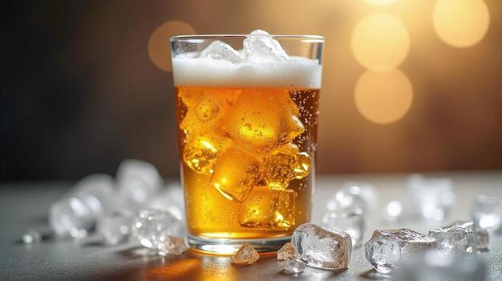

## Phases of matter

Solid

[interactive chart not shown]

Example: ice

Liquid

[interactive chart not shown]

Example: water

Gas

[interactive chart not shown]

Example: steam

## The solid state

Insulator

Conductor

[interactive chart not shown]

Example: diamond

[interactive chart not shown]

Example: copper wire

[figure not shown]

Transistor, invented in 1947.

Materials that can switch between both behaviors are called semiconductors. This property makes them the basis of modern electronics.

## In reality there are plenty of other phases

- Superfluids
- Liquid crystals
- Magnets
- Superconductors
- Topological materials

[figure not shown]

Superfluid helium

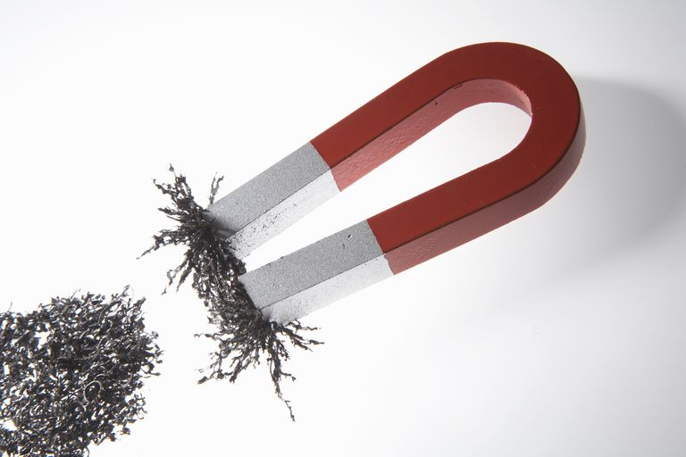

Magnetism

Temperature, magnetic fields, and electric fields are knobs that help us change from one phase to another.

## My two favorite phases

Superconductors

Topological materials

[interactive chart not shown]

Example: aluminum at very low temperature

Discovered in Leiden, The Netherlands in 1908

[interactive chart not shown]

Example: MnBi2Te4

Discovered in Grenoble, France in 1980

Both conduct perfectly!

Both need extremely low temperatures!

## My research: can we design a topological superconductor?

Can we design a topological superconductor?

## Why can’t we just find one?

Too many requirements:

- Superconductivity needs low magnetic fields
- Topological materials usually need high magnetic fields
- We want clear experimental signatures
- We want to be able to control/change it

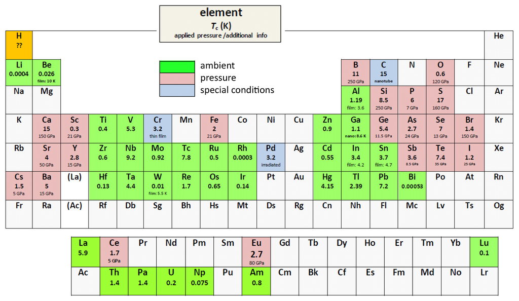

Periodic table of superconductors

## Approach 1: discover or synthesize the right material

TODO list:

1. Choose elements
2. Grow crystals
3. Tune composition, pressure, strain, or density
4. Look for the desired phase

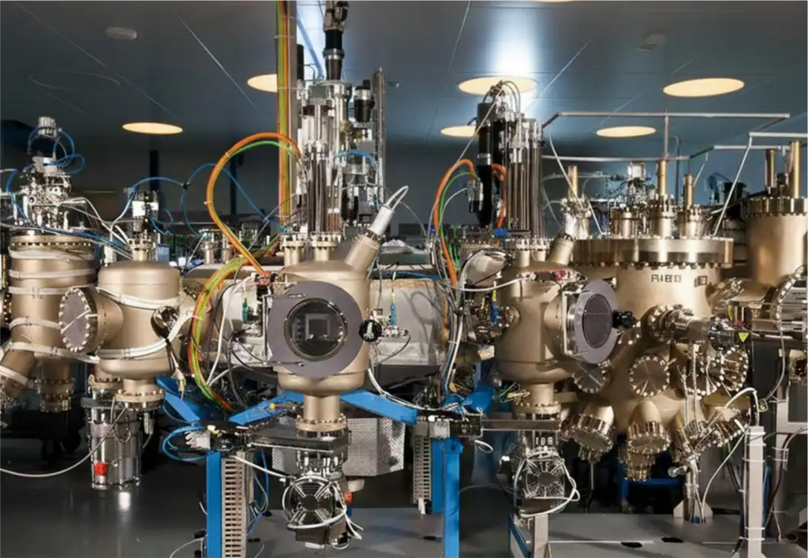

Molecular beam epitaxy system for growing quantum materials

## The discovery of 2D materials

Semiconductor stacks

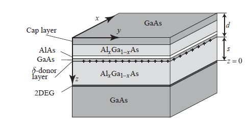

Technology from the 70s

Exfoliation

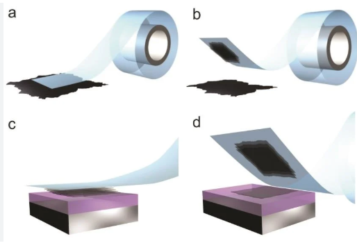

Method invented in 2004

We now know how to create “sheets” of different materials!

## Plot twist: the proximity effect ✨

[interactive chart not shown]

A semiconductor that is atomically close to a superconductor starts superconducting!

A quantum effect that allows materials to share properties over some distance!

## Approach 2: build a hybrid device

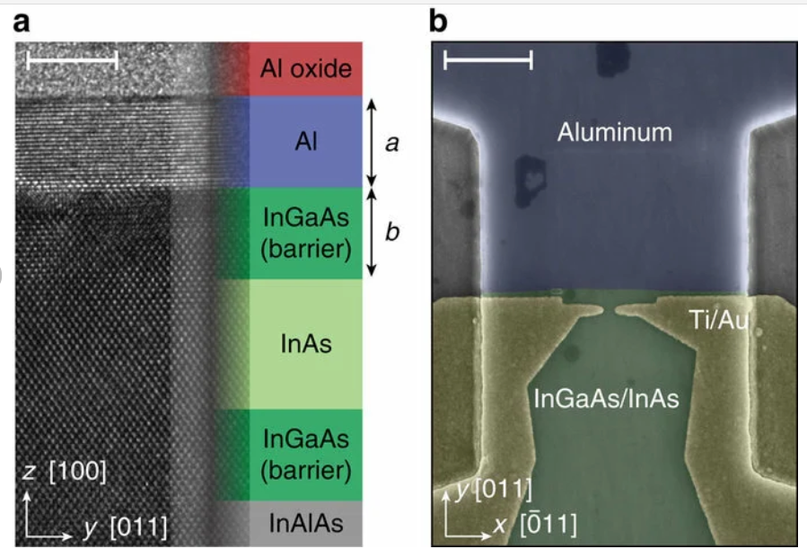

Hybrid superconducting-semiconducting device

## Example: planar topological superconductor

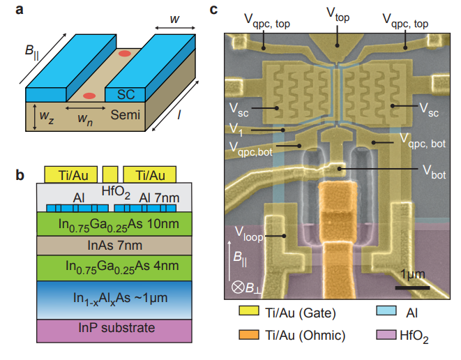

Device schematic and microscope image

## Designing new phases

## Designing new phases

**could** be possible thanks to the proximity effect

## Designing new phases

But stacking materials is not magic

- Interfaces must be extremely clean
- Each layer can disturb the others
- The useful signal can be tiny
- Geometry and disorder matter

Thank you!